# Week 3 Project - NYPD Dataset

Wes Westervelt

2023-02-20

## Import Libraries and Data

```r
library(tidyverse)
library(lubridate)
#data
nypd_df <- read_csv("https://data.cityofnewyork.us/api/views/833y-fsy8/rows.csv?accessType=DOWNLOAD")
```

## Initial Summary and Glimpse

Quick view to look for NA values and get an idea of the dataset

```r
summary(nypd_df)
```

```
##   INCIDENT_KEY        OCCUR_DATE         OCCUR_TIME           BORO
##  Min.   :  9953245   Length:25596       Length:25596      Length:25596
##  1st Qu.: 61593633   Class :character   Class1:hms        Class :character
##  Median : 86437258   Mode  :character   Class2:difftime   Mode  :character
##  Mean   :112382648                      Mode  :numeric
##  3rd Qu.:166660833
##  Max.   :238490103
##
##     PRECINCT      JURISDICTION_CODE LOCATION_DESC      STATISTICAL_MURDER_FLAG
##  Min.   :  1.00   Min.   :0.0000    Length:25596       Mode :logical
##  1st Qu.: 44.00   1st Qu.:0.0000    Class :character   FALSE:20668
##  Median : 69.00   Median :0.0000    Mode  :character   TRUE :4928
##  Mean   : 65.87   Mean   :0.3316
##  3rd Qu.: 81.00   3rd Qu.:0.0000
##  Max.   :123.00   Max.   :2.0000
##                   NA's   :2
##  PERP_AGE_GROUP       PERP_SEX          PERP_RACE         VIC_AGE_GROUP
##  Length:25596       Length:25596       Length:25596       Length:25596
##  Class :character   Class :character   Class :character   Class :character
##  Mode  :character   Mode  :character   Mode  :character   Mode  :character
##
##
##
##
##    VIC_SEX            VIC_RACE           X_COORD_CD        Y_COORD_CD
##  Length:25596       Length:25596       Min.   : 914928   Min.   :125757
##  Class :character   Class :character   1st Qu.:1000011   1st Qu.:182782
##  Mode  :character   Mode  :character   Median :1007715   Median :194038
##                                        Mean   :1009455   Mean   :207894
##                                        3rd Qu.:1016838   3rd Qu.:239429
##                                        Max.   :1066815   Max.   :271128
##
##     Latitude       Longitude        Lon_Lat
##  Min.   :40.51   Min.   :-74.25   Length:25596
##  1st Qu.:40.67   1st Qu.:-73.94   Class :character
##  Median :40.70   Median :-73.92   Mode  :character
##  Mean   :40.74   Mean   :-73.91
##  3rd Qu.:40.82   3rd Qu.:-73.88
##  Max.   :40.91   Max.   :-73.70
##
```

```r
glimpse(nypd_df)
```

```
## Rows: 25,596
## Columns: 19
## $ INCIDENT_KEY            <dbl> 236168668, 231008085, 230717903, 237712309, 22~
## $ OCCUR_DATE              <chr> "11/11/2021", "07/16/2021", "07/11/2021", "12/~
## $ OCCUR_TIME              <time> 15:04:00, 22:05:00, 01:09:00, 13:42:00, 20:00~
## $ BORO                    <chr> "BROOKLYN", "BROOKLYN", "BROOKLYN", "BROOKLYN"~
## $ PRECINCT                <dbl> 79, 72, 79, 81, 113, 113, 42, 52, 34, 75, 32, ~
## $ JURISDICTION_CODE       <dbl> 0, 0, 0, 0, 0, 0, 0, 0, 0, 0, 0, 2, 2, 0, 0, 0~
## $ LOCATION_DESC           <chr> NA, NA, NA, NA, NA, NA, "COMMERCIAL BLDG", NA,~
## $ STATISTICAL_MURDER_FLAG <lgl> FALSE, FALSE, FALSE, FALSE, FALSE, TRUE, TRUE,~
## $ PERP_AGE_GROUP          <chr> NA, "45-64", "<18", NA, NA, NA, NA, NA, NA, "2~
## $ PERP_SEX                <chr> NA, "M", "M", NA, NA, NA, NA, NA, NA, "M", "M"~
## $ PERP_RACE               <chr> NA, "ASIAN / PACIFIC ISLANDER", "BLACK", NA, N~
## $ VIC_AGE_GROUP           <chr> "18-24", "25-44", "25-44", "25-44", "25-44", "~
## $ VIC_SEX                 <chr> "M", "M", "M", "M", "M", "M", "M", "M", "M", "~
## $ VIC_RACE                <chr> "BLACK", "ASIAN / PACIFIC ISLANDER", "BLACK", ~
## $ X_COORD_CD              <dbl> 996313, 981845, 996546, 1001139, 1050710, 1051~
## $ Y_COORD_CD              <dbl> 187499, 171118, 187436, 192775, 184826, 196646~
## $ Latitude                <dbl> 40.68132, 40.63636, 40.68114, 40.69579, 40.673~
## $ Longitude               <dbl> -73.95651, -74.00867, -73.95567, -73.93910, -7~
## $ Lon_Lat                 <chr> "POINT (-73.95650899099996 40.68131820000008)"~
```

## Tidy Dataset

```r
nypd_tidy <- nypd_df %>%
    mutate( PERP_AGE_GROUP = if_else(is.na(PERP_AGE_GROUP), "U", PERP_AGE_GROUP),
PERP_SEX = if_else(is.na(PERP_SEX), "UNKNOWN", PERP_SEX),
PERP_RACE = if_else(is.na(PERP_RACE), "UNKNOWN", PERP_RACE),
LOCATION_DESC = if_else(is.na(LOCATION_DESC), "NONE", LOCATION_DESC))

nypd_tidy <- select(nypd_df, INCIDENT_KEY, OCCUR_DATE, BORO,
LOCATION_DESC, STATISTICAL_MURDER_FLAG, PERP_AGE_GROUP, PERP_SEX,
PERP_RACE, VIC_AGE_GROUP, VIC_SEX, VIC_RACE, X_COORD_CD, Y_COORD_CD)
```

## Table 1

Further breakdown of the tidy dataset in more usable format

```r
tabledate<-select(nypd_tidy, INCIDENT_KEY, OCCUR_DATE)

#split string
tabledate<- separate(tabledate, col=OCCUR_DATE, into=c('day', 'month', 'year'), sep='/')


#GROUPBY
 tabledate<-tabledate %>%
     group_by(year) %>%
     summarise(incident_count = n_distinct(INCIDENT_KEY))
```

## Visual 1 - Time series of incident count line graph

Line graph to see incidents over time

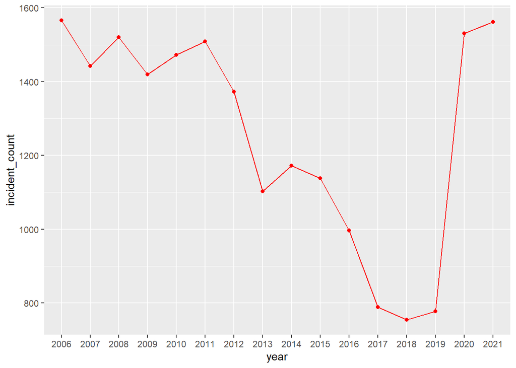

```r
ggplot(data=tabledate, aes(x=year, y=incident_count, group=1)) +
    geom_line(color="red")+
    geom_point(color="red")
```

## Table 2

Second further breakdown of the tidy dataset

```r
pivotw <- nypd_tidy %>%
  group_by(VIC_RACE, VIC_SEX, VIC_AGE_GROUP) %>%
  summarise(count = n()) %>%
  pivot_wider(names_from = VIC_AGE_GROUP, values_from = count)
pivot <- nypd_tidy %>%
  group_by(VIC_RACE, VIC_SEX, VIC_AGE_GROUP) %>%
  summarise(count = n())
```

## Visual 2 - Gender Bar Graph

Bar graph with gender and race of victim breakdown

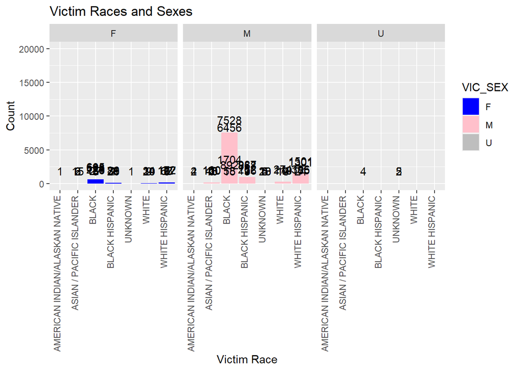

```r
ggplot(pivot, aes(x = VIC_RACE, y = count, fill = VIC_SEX)) +
    geom_bar(stat = "identity", position = "dodge") +
    scale_y_continuous(limits = c(0, 20000)) +
    geom_text(aes(label = count), vjust = -1) +
    labs(title = "Victim Races and Sexes", x = "Victim Race", y = "Count") +
    facet_wrap(~ VIC_SEX) +
    theme(axis.text.x = element_text(angle = 90, vjust=0,  hjust =1 ))+
    scale_fill_manual(values = c("blue", "pink", "gray"))
```

## Visual 3 - 3 Variable Bar Graph Breakdown

Bar graph with Victim: Gender, Race, and Age to see relationships

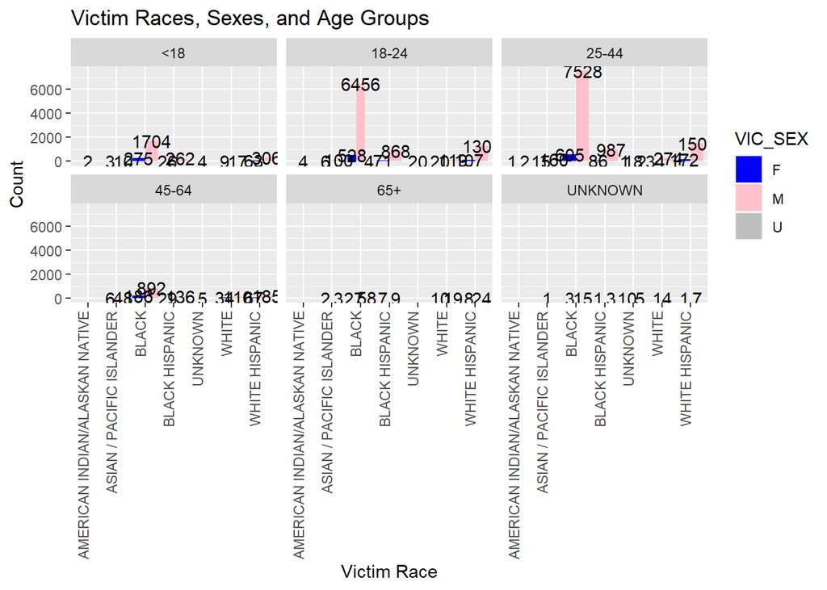

```r
ggplot(pivot, aes(x = VIC_RACE, y = count, fill = VIC_SEX)) +
     geom_bar(stat = "identity", position = "dodge") +
     geom_text(aes(label = count), ,position = position_dodge(width = 0.9), vjust = 0.5) +
     facet_wrap(~ VIC_AGE_GROUP) +
     labs(title = "Victim Races, Sexes, and Age Groups", x = "Victim Race", y = "Count") +
     theme(axis.text.x = element_text(angle = 90, vjust=0,  hjust =1 ))+
     scale_fill_manual(values = c("blue", "pink", "gray"))
```

## Analysis

For the first visual (line graph), I wanted to see how many incidents occurred over time, and to see if there were any spikes or dips. As suspected, there was a huge dip starting in 2016 through 2019, but then spikes again in 2020. I believe the spike in 2020 is due to everyone being at home within the pandemic and emotions were running high during that time, with fear being the primary factor of influence.

For the second and third visuals, I wanted to see if there was a trend between first the two variables of gender and ethnicity to see the data set on a smaller plan, and then expanded it to include the third variable of age. From those two charts, we can conclude that Black Males between the ages of 25-44 are the highest incident victims of crime in NY. Further analysis would need to look at other features such as location/neighborhood and other outside factors not gathered in the dataset.

## Model

Predicts Y coordinate given X coordinate is known

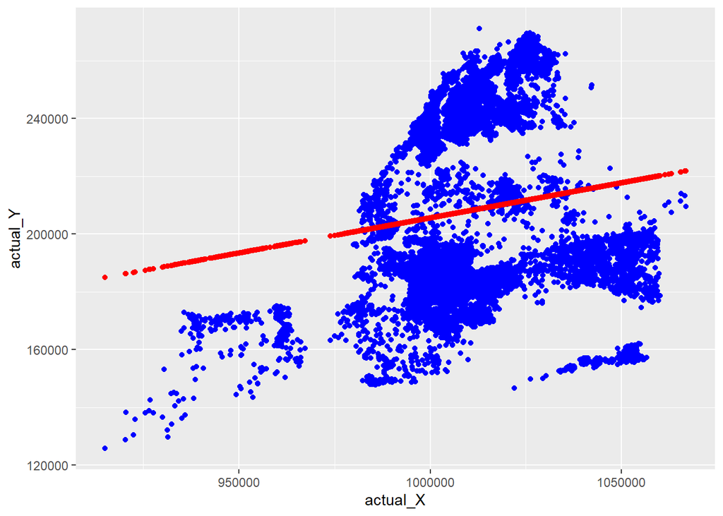

```r
model <- lm(Y_COORD_CD ~ X_COORD_CD, data = nypd_tidy)

pred <- predict(model)

nypd_tidy$predicted <- pred

ggplot(data.frame(actual_X = nypd_tidy$X_COORD_CD, actual_Y =  nypd_tidy$Y_COORD_CD, predicted = pred),
    aes(x = actual_X, y = actual_Y))+
    geom_point(aes(x =actual_X, y = actual_Y), color = "blue") +
    geom_point(aes(x =actual_X, y=pred), color ="red")
```

The model above appears to predict a linear relationship

## Bias

Overall, I do not believe there is any bias in myself with this data set as I holistically included all gender, race and age groupings to not focus on one group more than the other. Additionally, the data set itself does not have an inherit bias as it’s static data, however, being the data would need to be report, if not reported (which with the missing values this could be the case) it could lead to a bias, with one grouping getting more dataponts because they are reporting more than other groups.